# Run 2 Sample Taxonomy Clean Up

M Fisher

2022-06-24

# Description

Clean up the taxonomic information for each crab (+technical replicate). This involves:

1. Removing the ASVs in the positive and negative controls
2. Removing predator DNA
3. Removing non-target bacteria, fungal DNA
4. Removing DNA from species too small to be targeted prey, e.g., copepods, etc.

Specify user directories

```r
dada_dir    <- 'data/dada2'
blast_dir   <- 'data/blast'
outdir      <- 'data'
```

What are the names of the processed blast file with taxonomy from script 6?

```r
# hashes with unique staxids
blast_file <- 'leray_r2_sample_blast_lca_taxonomy.csv'
```

What is the location / name of the metadata file for this sequencing run?

```r
run_metadat_file <- 'data/EGC_WASS_Run2_samples.csv'
```

And the run number and the marker

```r
run.num <- 2
marker <-'leray'
```

# Read in data

Clean up the blast data, separate the sample-rep into a sample ID and replicate number, and then join to metadata information.

```r
blast.dat.filter <- blast.dat %>%
  dplyr::select(1:14) %>%
  mutate(type=ifelse(grepl("Positive", sample_id) | grepl("Negative",sample_id), "Control","Sample")) %>%
  separate(col=sample_id, into=c("sample","tech"), sep=-1,remove=FALSE) %>%
  mutate(tech=as.numeric(as.factor(tolower(tech)))) %>%
  mutate(sample=ifelse(type=="Sample",str_sub(sample,start=1,end=-2),sample),
         tech=ifelse(type=="Sample",tech,NA))

blast.dat.filter <- left_join(blast.dat.filter, metadat,by=c("Sample_name"="sample_name","sample_id"="sample_label","Locus")) %>% dplyr::select(-file1)
dim(blast.dat.filter)
```

```
## [1] 947  19
```

# Identify Taxonomy for Removal

To easier track how much data is being removed, I’m going to classify each hash as (1) to remove, and (2) reason for removal. then in the next section, I’ll filter the data and check out the prey taxa.

### Controls

get the hashes in the controls.

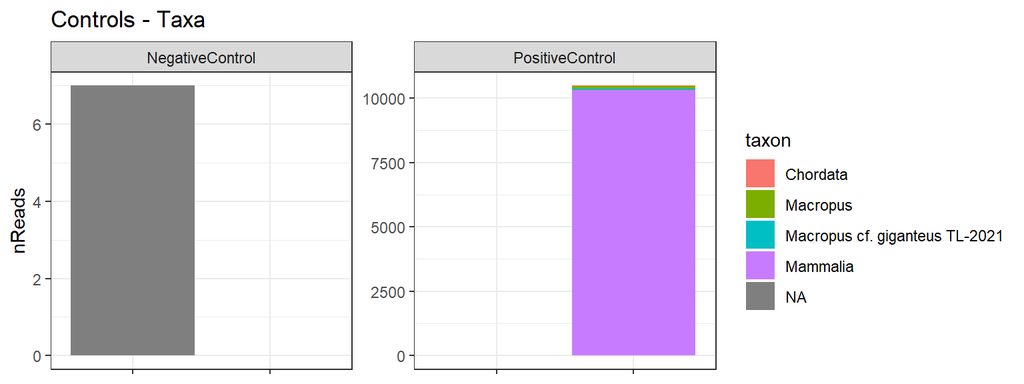

mark in the rest of the data. there was also some human DNA (oops!) that needs to be removed, which I’ve included in the ‘control’ category.

```r
blast.dat.filter <- blast.dat.filter %>%
  filter(type=="Sample") %>%
  mutate(control_rm=ifelse(Hash %in% control_dat$Hash,1,0))
```

### Predator DNA

Any Green crab DNA will be marked as ‘predator’ DNA and removed.

- Carcinus maenas (species)
- Carcinus (genus)

```r
blast.dat.filter <- blast.dat.filter %>%
  mutate(predator_rm=ifelse(control_rm==0 & (taxon =="Carcinus maenas" | taxon =="Carcinus aestuarii" | taxon =="Carcinus"), 1, 0))
```

### Bacterial, fungal etc. DNA

The data has the following phylums; and when phylum is missing, these are the classes :

```
##  [1] "Arthropoda"      NA                "Ascomycota"      "Oomycota"
##  [5] "Chordata"        "Mollusca"        "Bacillariophyta" "Rotifera"
##  [9] "Bacteroidetes"   "Discosea"        "Cnidaria"        "Annelida"
## [13] "Proteobacteria"  "Heterolobosea"   "Platyhelminthes" "Tubulinea"
## [17] "Chlorophyta"     "Basidiomycota"
```

```
## [1] NA                 "Choanoflagellata" "Phaeophyceae"     "Dinophyceae"
```

These are the bacterial / fungal / amoeba / protist taxa to remove:

```r
to_remove_phyla <- c("Proteobacteria","Planctomycetes","Oomycota","Actinobacteria","Basidiomycota","Ascomycota",
                     "Discosea","Evosea","Bacteroidetes","Heterolobosea")
to_remove_class <- c("Dinophyceae")
to_remove_taxa <- c("Choanoflagellata","Hematodinium sp.","Naegleria","Euamoebida","Amoebozoa sp.","Monosiga brevicollis")

blast.dat.filter <- blast.dat.filter %>%
  mutate(baf_rm=ifelse(control_rm==0 & (phylum %in% to_remove_phyla | taxon %in% to_remove_taxa | class %in% to_remove_class), 1, 0))
```

### Unlikely prey

Some items that left behind DNA in the crab stomach are unlikely to be targeted prey – they could have been ingested while the crab was eating something else, or they could have been in the stomach of the crab’s prey.

I’m going to assume that the following are not targeted by the crab as prey:

- diatoms (Bacillariophyta)
- rotifers (Rotifera)
- small algae & plankton

Here are the algae / plant taxa:

```
## # A tibble: 20 x 4
##    phylum          class               order            taxon
##    <chr>           <chr>               <chr>            <chr>
##  1 Bacillariophyta Coscinodiscophyceae Paraliales       Paralia sulcata
##  2 Rotifera        Eurotatoria         Ploima           Euchlanis dilatata
##  3 <NA>            Phaeophyceae        Fucales          Ascophyllum nodosum
##  4 Bacillariophyta Bacillariophyceae   <NA>             Bacillariophyceae
##  5 Bacillariophyta Mediophyceae        <NA>             Mediophyceae
##  6 Bacillariophyta Bacillariophyceae   Cymbellales      Cymbellaceae
##  7 Bacillariophyta Bacillariophyceae   Cymbellales      Paraplaconeis kornevae
##  8 Bacillariophyta Coscinodiscophyceae <NA>             Coscinodiscophyceae
##  9 <NA>            Phaeophyceae        Ectocarpales     Ectocarpus
## 10 Bacillariophyta Coscinodiscophyceae Thalassiosirales Skeletonema menzelii
## 11 Bacillariophyta Bacillariophyceae   Bacillariales    Pseudo-nitzschia cuspid~
## 12 Rotifera        Eurotatoria         <NA>             Eurotatoria
## 13 Bacillariophyta <NA>                <NA>             Bacillariophyta
## 14 Chlorophyta     Pyramimonadophyceae Pyramimonadales  Cymbomonas tetramitifor~
## 15 Bacillariophyta Fragilariophyceae   Fragilariales    Asterionellopsis
## 16 Chlorophyta     Mamiellophyceae     Mamiellales      Micromonas pusilla
## 17 <NA>            Phaeophyceae        Fucales          Fucus distichus
## 18 <NA>            Phaeophyceae        Ectocarpales     Chordariaceae
## 19 <NA>            Phaeophyceae        Ectocarpales     Planosiphon gracilis
## 20 Bacillariophyta Coscinodiscophyceae Melosirales      Melosira nummuloides
```

From that list, I’m going to remove the following:

```r
to_remove_phyla <- c("Bacillariophyta", "Rotifera")
to_remove_taxa  <- c("Cymbomonas tetramitiformis","Micromonas pusilla","Planosiphon gracilis")

blast.dat.filter <- blast.dat.filter %>%
  mutate(too_small_rm=ifelse(control_rm==0 & (phylum %in% to_remove_phyla | taxon %in% to_remove_taxa), 1, 0))
```

There are probably a range of other organisms that are not target prey, but I’m going to leave everything else in for now until I have a crab biologist weigh in.

## Summary

Look at the proportion of reads in each ‘removal’ category, for each sample.

Overall summary, by site:

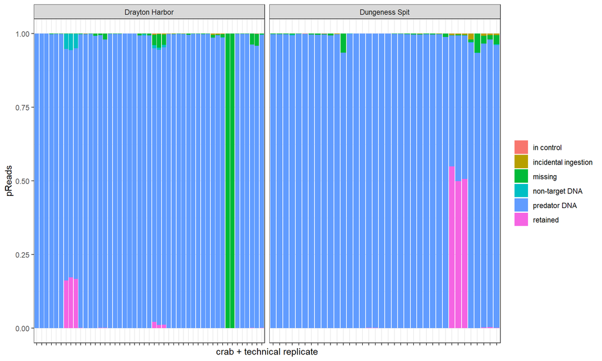

```r
ggplot(plotdat, aes(x=sample_id,y=pReads,fill=reason)) +
  geom_col() +
  facet_grid(cols=vars(site), scales="free") +
  xlab("crab + technical replicate") +
  theme_bw() + theme(axis.text.x=element_blank(), legend.title=element_blank())
```

By sample type:

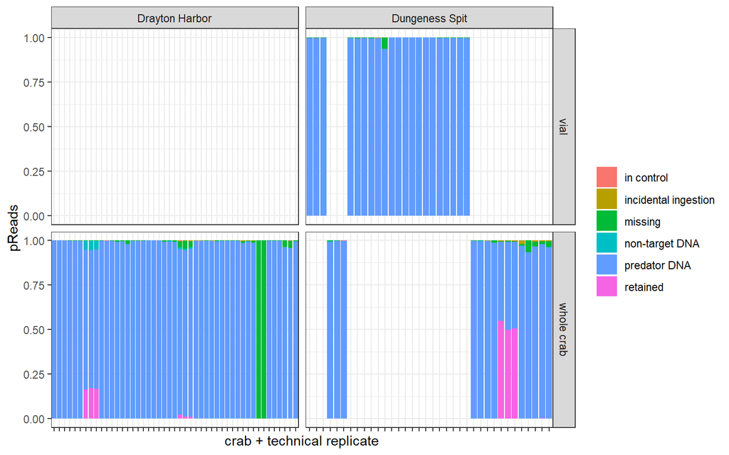

whew. how many crab have data from actual potential prey??

```r
length(unique(summary_dat$sample))
```

```
## [1] 28
```

```r
length((summary_dat %>% group_by(sample,reason) %>% summarise(sum(nReads)) %>% filter(reason=="retained"))$sample)
```

```
## [1] 14
```

# Write out Taxonomy

remove all of the hashes marked for removal above.

```r
blast.dat.out <- blast.dat.filter %>%
  filter(!is.na(rank)) %>%
  filter(control_rm==0 & predator_rm==0 & baf_rm==0 & too_small_rm==0) %>%
  dplyr::select(-c(control_rm,predator_rm,baf_rm,too_small_rm))
```

write out.

```r
write_csv(blast.dat.out, here(outdir, paste0(marker,"_r",run.num,"_blast_taxonomy_filtered.csv")))
```